# REN-007 Adjusted Analyses Report: All-Cohort Composite-Component Event Subset

# 1 Population Summary

This report reproduces the adjusted analysis workflow from the project R Markdown analyses, but it restricts the cohort to subjects who had at least one of the component events referenced in the PH-10.1c composite table categories: death, AKI requiring dialysis, or 30-day cardiopulmonary readmission.

Using all available `ADSL` records, the cohort included 454 randomized subjects overall and 418 evaluable `ITT1FL = "Y"` subjects. Applying the component-event subset definition retained 37 subjects total: 19 on `RBT-1` and 18 on `Placebo`.

The exact subject listing used for this report is also written to output/allcohort_component_event_subjects.csv, with overlap counts in output/allcohort_component_event_overlap_summary.csv.

## 1.2 Component Counts by Treatment

**Component Event Counts in the All-Cohort Event-Positive Subset**

| Treatment | Subjects | Death | AKI requiring dialysis | 30-day cardiopulmonary readmission | At least 2 component events |
| --- | --- | --- | --- | --- | --- |
| Placebo | 18 | 7 | 6 | 11 | 6 |
| RBT-1 | 19 | 3 | 6 | 13 | 3 |

## 1.3 Subject Listing

**Subjects Meeting the Composite-Component Criteria**

Derived from the full evaluable cohort using the PH-10.1c component criteria

[output not shown]

## 1.4 Overlap Summary

**Overlap of Component Events by Treatment**

| Event profile | Subjects |
| --- | --- |
| Placebo |  |
| 30-day cardiopulmonary readmission only | 10 |
| Death + AKI requiring dialysis | 5 |
| AKI requiring dialysis only | 1 |
| Death + 30-day cardiopulmonary readmission | 1 |
| Death only | 1 |
| RBT-1 |  |
| 30-day cardiopulmonary readmission only | 13 |
| AKI requiring dialysis only | 3 |
| Death + AKI requiring dialysis | 3 |

## 1.5 Statistical Analysis

The analysis code follows the same structure as the existing project reports: treatment groups are `Placebo` and `RBT-1`, medical-history burden is derived from `ADMH`, clinical baseline covariates are derived from `ADSC`, efficacy endpoints are modeled with propensity-adjusted regression, and postoperative laboratory endpoints are aligned to surgery date and analyzed in first-week and long-term windows. Because this subset contains only 37 subjects, the smaller-sample models are allowed to return descriptive non-estimable notes instead of stopping the report knit.

**Population Summary by Treatment Group**

Restricted to all-cohort subjects with at least one component event

| **Characteristic** | **Overall** N = 37<sup>1</sup> | **Placebo** N = 18<sup>1</sup> | **RBT-1** N = 19<sup>1</sup> | **p-value**<sup>2</sup> |
| --- | --- | --- | --- | --- |
| Age group |  |  |  | 0.2 |
| <65 years | 12 (32%) | 4 (22%) | 8 (42%) |  |
| >=65 years | 25 (68%) | 14 (78%) | 11 (58%) |  |
| Sex |  |  |  | 0.6 |
| F | 15 (41%) | 8 (44%) | 7 (37%) |  |
| M | 22 (59%) | 10 (56%) | 12 (63%) |  |
| Total pre-surgery medical history records | 22 (8) | 22 (9) | 21 (8) | 0.7 |
| Medical history burden quartile |  |  |  | 0.010 |
| Q1 (lowest) | 10 (27%) | 5 (28%) | 5 (26%) |  |
| Q2 | 9 (24%) | 1 (5.6%) | 8 (42%) |  |
| Q3 | 9 (24%) | 8 (44%) | 1 (5.3%) |  |
| Q4 (highest) | 9 (24%) | 4 (22%) | 5 (26%) |  |
| Any vascular-disorder history | 36 (97%) | 17 (94%) | 19 (100%) | 0.5 |
| Any metabolic/nutrition history | 35 (95%) | 16 (89%) | 19 (100%) | 0.2 |
| Any respiratory history | 29 (78%) | 13 (72%) | 16 (84%) | 0.4 |
| Any renal/urinary history | 19 (51%) | 11 (61%) | 8 (42%) | 0.2 |
| Any nervous-system history | 26 (70%) | 14 (78%) | 12 (63%) | 0.3 |
| Any social-circumstance history | 21 (57%) | 7 (39%) | 14 (74%) | 0.033 |
| ADSC chronic kidney disease | 13 (35%) | 8 (44%) | 5 (26%) | 0.2 |
| ADSC diabetes | 20 (54%) | 12 (67%) | 8 (42%) | 0.13 |
| ADSC hypertension | 35 (95%) | 17 (94%) | 18 (95%) | >0.9 |
| ADSC coronary artery disease | 19 (51%) | 9 (50%) | 10 (53%) | 0.9 |
| ADSC peripheral artery disease | 3 (8.1%) | 3 (17%) | 0 (0%) | 0.11 |
| ADSC urgent surgery | 8 (22%) | 5 (28%) | 3 (16%) | 0.4 |
| ADSC heart failure status positive | 14 (38%) | 8 (44%) | 6 (32%) | 0.4 |
| ADSC NYHA class III/IV | 10 (27%) | 5 (28%) | 5 (26%) | >0.9 |

<sup>1</sup> n (%); Mean (SD)  
<sup>2</sup> Pearson’s Chi-squared test; Wilcoxon rank sum test; Fisher’s exact test

# 2 Adjusted Efficacy Analyses

## 2.1 Binary Endpoints

**Adjusted Binary Efficacy Results**

Logistic regression adjusted using pre-surgery medical history summary

| Endpoint | Model | Odds ratio (RBT-1 vs Placebo) | 95%% CI | P-value | Model note |
| --- | --- | --- | --- | --- | --- |
| Death | Logistic regression | 0.29 | 0.06 to 1.40 | 0.124 | NA |
| AKI requiring dialysis | Logistic regression | 0.91 | 0.23 to 3.63 | 0.891 | NA |
| 30-day cardiopulmonary readmission | Logistic regression | 1.37 | 0.35 to 5.35 | 0.648 | NA |

## 2.2 ICU Days

**Adjusted ICU Days Result**

| Endpoint | Model | Approx. % change (RBT-1 vs Placebo) | 95%% CI (log scale) | P-value | Model note |
| --- | --- | --- | --- | --- | --- |
| ICU days | Linear regression on log1p(ICU days) | -47.6% | -1.47 to 0.18 | 0.136 | NA |

## 2.3 Forest Plot

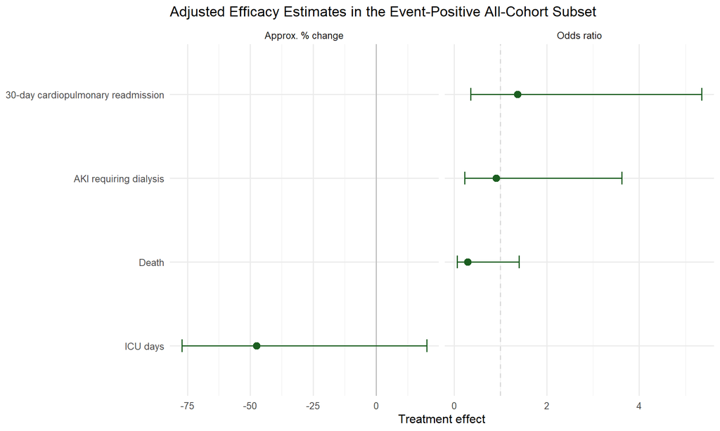

# 3 Adjusted Lab Analyses

## 3.1 First-Week Longitudinal

**First-Week Longitudinal Laboratory Results**

[output not shown]

## 3.2 Long-Term Follow-Up

**Long-Term Laboratory Models**

| Lab parameter | Subjects | Placebo | RBT-1 | Baseline adjusted | Approx. % diff (RBT-1 vs Placebo) | 95%% CI | P-value | Model note |
| --- | --- | --- | --- | --- | --- | --- | --- | --- |
| GFRECRT | 29 | 13 | 16 | TRUE | 10.1% | -10.8% to 35.9% | 0.380 | NA |
| SCREAT | 29 | 13 | 16 | TRUE | -4.4% | -13.9% to 6.2% | 0.411 | NA |

## 3.3 Availability

**Laboratory Data Availability and Summary Values**

| Lab parameter | Treatment | Subjects | With baseline | Mean outcome | Median outcome |
| --- | --- | --- | --- | --- | --- |
| Immediate (Days 1-7) |  |  |  |  |  |
| GFRECRT | Placebo | 18 | 18 | 45.36 | 36.33 |
| GFRECRT | RBT-1 | 19 | 19 | 45.44 | 53.09 |
| LACTICAC | Placebo | 18 | 16 | 3.63 | 2.55 |
| LACTICAC | RBT-1 | 18 | 18 | 3.66 | 2.00 |
| OXYSAT | Placebo | 18 | 18 | 95.76 | 96.60 |
| OXYSAT | RBT-1 | 19 | 19 | 95.66 | 97.90 |
| SCREAT | Placebo | 18 | 18 | 1.76 | 1.60 |
| SCREAT | RBT-1 | 19 | 19 | 1.86 | 1.38 |
| TROPONI | Placebo | 16 | 14 | 15556.77 | 3598.50 |
| TROPONI | RBT-1 | 18 | 17 | 8789.40 | 7682.00 |
| Long-term (>= Day 28, nearest to Day 30) |  |  |  |  |  |
| GFRECRT | Placebo | 13 | 13 | 64.07 | 68.50 |
| GFRECRT | RBT-1 | 16 | 16 | 71.80 | 66.65 |
| SCREAT | Placebo | 13 | 13 | 1.20 | 1.04 |
| SCREAT | RBT-1 | 16 | 16 | 1.03 | 0.97 |

## 3.4 Lab Forest Plot

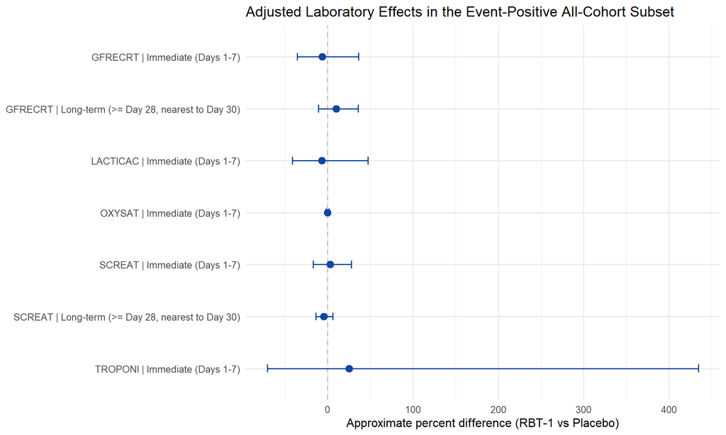

## 3.5 First-Week Trajectory Plot

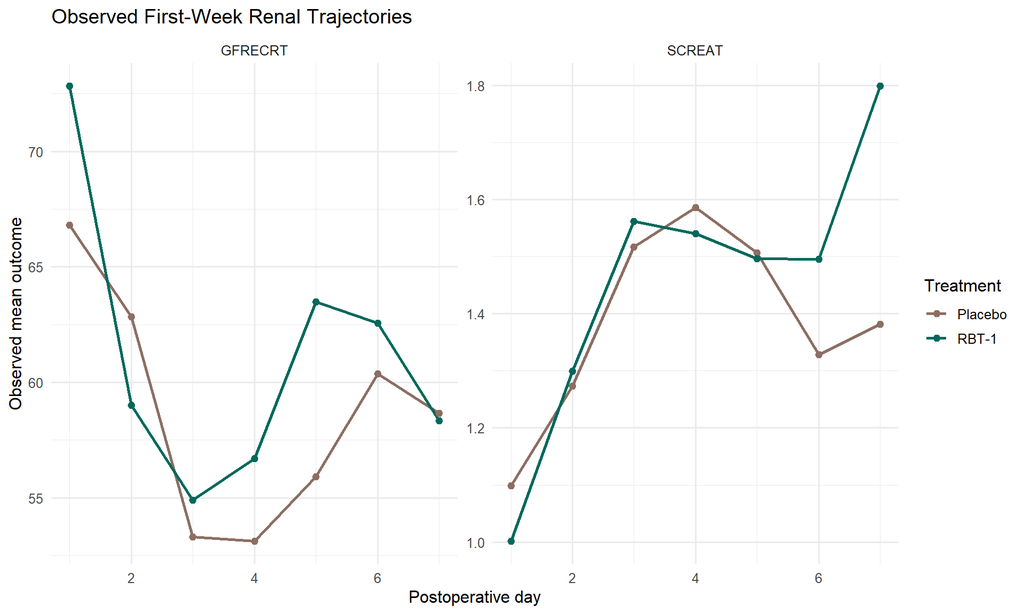

## 3.6 Adjusted Renal First-Week Profiles

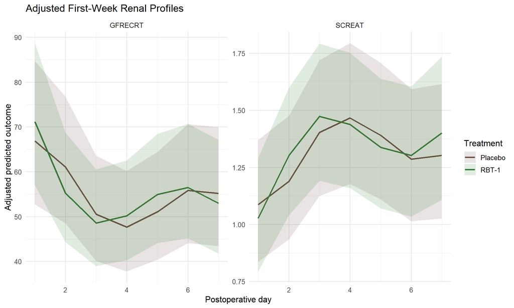

# 4 Explicit Renal Covariate Models

## 4.1 Treatment Effects

**Explicit Renal Covariate Models: Treatment Effects**

| Renal parameter | Subjects | Placebo | RBT-1 | Approx. % diff (RBT-1 vs Placebo) | 95%% CI | P-value | Model note |
| --- | --- | --- | --- | --- | --- | --- | --- |
| Immediate (Days 1-7) |  |  |  |  |  |  |  |
| GFRECRT | 37 | 18 | 19 | 7.0% | -29.3% to 62.0% | 0.753 | NA |
| SCREAT | 37 | 18 | 19 | -5.5% | -25.9% to 20.6% | 0.658 | NA |
| Long-term (>= Day 28, nearest to Day 30) |  |  |  |  |  |  |  |
| GFRECRT | 29 | 13 | 16 | 1.7% | -33.1% to 54.8% | 0.937 | NA |
| SCREAT | 29 | 13 | 16 | -0.2% | -19.1% to 23.1% | 0.985 | NA |

## 4.2 Coefficients

**Explicit Renal Model Coefficients**

| Renal parameter | Coefficient | Estimate | Std. error | t-statistic | P-value |
| --- | --- | --- | --- | --- | --- |
| Immediate (Days 1-7) |  |  |  |  |  |
| GFRECRT | (Intercept) | -3.812 | 2.642 | -1.44 | 0.171 |
| GFRECRT | trt_ind | 0.068 | 0.212 | 0.32 | 0.753 |
| GFRECRT | AGE | 0.005 | 0.012 | 0.43 | 0.676 |
| GFRECRT | sex_male | 0.029 | 0.243 | 0.12 | 0.908 |
| GFRECRT | total_mh_records | -0.007 | 0.027 | -0.24 | 0.812 |
| GFRECRT | unique_body_systems | 0.045 | 0.069 | 0.66 | 0.519 |
| GFRECRT | cardiac_terms | -0.045 | 0.051 | -0.88 | 0.392 |
| GFRECRT | vascular_any | -1.861 | 1.045 | -1.78 | 0.097 |
| GFRECRT | metabolic_any | 0.712 | 0.807 | 0.88 | 0.392 |
| GFRECRT | respiratory_any | -0.218 | 0.318 | -0.69 | 0.504 |
| GFRECRT | renal_any | -0.040 | 0.374 | -0.11 | 0.917 |
| GFRECRT | nervous_any | -0.190 | 0.255 | -0.74 | 0.470 |
| GFRECRT | social_any | 0.255 | 0.265 | 0.97 | 0.351 |
| GFRECRT | sc_ckd_any | 0.592 | 0.391 | 1.51 | 0.153 |
| GFRECRT | sc_diab_any | 0.047 | 0.249 | 0.19 | 0.853 |
| GFRECRT | sc_hyp_any | 1.462 | 0.529 | 2.76 | 0.015 |
| GFRECRT | sc_cad_any | -0.065 | 0.233 | -0.28 | 0.785 |
| GFRECRT | sc_pad_any | 1.211 | 0.562 | 2.15 | 0.049 |
| GFRECRT | sc_urgent | -0.981 | 0.322 | -3.05 | 0.009 |
| GFRECRT | sc_hf_status | -0.123 | 0.288 | -0.43 | 0.675 |
| GFRECRT | sc_nyha_34 | 0.036 | 0.358 | 0.10 | 0.922 |
| GFRECRT | sc_lvef | -0.009 | 0.010 | -0.87 | 0.397 |
| GFRECRT | log1p(baseline_lab) | 1.776 | 0.486 | 3.66 | 0.003 |
| SCREAT | (Intercept) | -0.594 | 0.731 | -0.81 | 0.430 |
| SCREAT | trt_ind | -0.056 | 0.124 | -0.45 | 0.658 |
| SCREAT | AGE | 0.000 | 0.006 | 0.02 | 0.987 |
| SCREAT | sex_male | -0.094 | 0.169 | -0.55 | 0.588 |
| SCREAT | total_mh_records | 0.001 | 0.016 | 0.07 | 0.944 |
| SCREAT | unique_body_systems | -0.018 | 0.040 | -0.45 | 0.659 |

[output cut: 60 more lines]

## 4.3 Renal Forest Plot

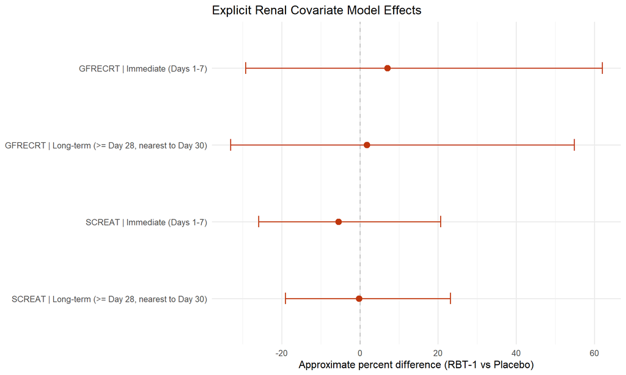